# 705604096_stats101c_hw5

Jade Gregory

2023-11-08

## Question 1

```r
births <- read.csv("birthsnewone.csv")
head(births)
```

```
##   X Institution.type Plurality.of.birth Gender Race.of.child  Race
## 1 1                1                  1      2             1 White
## 2 2                1                  1      2             1 White
## 3 3                1                  1      2             1 White
## 4 4                1                  1      2             2 Black
## 5 5                1                  1      1             2 Black
## 6 6                1                  1      2             1 White
##   Age.of.father Age.of.mother Education.of.father..years.
## 1            50            24                          12
## 2            19            18                           9
## 3            37            35                          17
## 4            39            31                          11
## 5            20            19                          11
## 6            30            27                          16
##   Education.of.mother..years. Total.Preg BDead Terms Date.LBirth Month.LBirth
```

[output cut: 34 more lines]

```r
set.seed(123456789)
i = 1:dim(births)[1]
i.train <- sample(i, 5000, replace = FALSE)
B.train = births[i.train,]
B.test = births[-i.train, ]
head(B.train)
```

```
##         X Institution.type Plurality.of.birth Gender Race.of.child  Race
## 4468 4468                1                  1      1             8 Other
## 3138 3138                1                  1      2             1 White
## 1895 1895                1                  1      2             1 White
## 6160 6160                1                  1      1             3 Other
## 3051 3051                1                  1      2             1 White
## 1580 1580                1                  1      1             1 White
##      Age.of.father Age.of.mother Education.of.father..years.
## 4468            36            33                          14
## 3138            39            36                           3
## 1895            37            42                          16
## 6160            27            27                          12
## 3051            43            34                           6
## 1580            40            37                          12
##      Education.of.mother..years. Total.Preg BDead Terms Date.LBirth
```

[output cut: 34 more lines]

```r
# linear model
births_lm <- lm(Birth.Weight..g. ~ . - X, data = B.train)
summary(births_lm)
```

```
##
## Call:
## lm(formula = Birth.Weight..g. ~ . - X, data = B.train)
##
## Residuals:
##     Min      1Q  Median      3Q     Max
## -341.28 -110.94   -0.63  110.16  640.26
##
## Coefficients: (4 not defined because of singularities)
##                               Estimate Std. Error t value Pr(>|t|)
## (Intercept)                 -1.569e+01  9.397e+01  -0.167 0.867428
## Institution.type            -5.565e+00  5.676e+00  -0.980 0.326905
## Plurality.of.birth          -4.018e+01  1.121e+01  -3.586 0.000340 ***
## Gender                      -9.652e+00  3.937e+00  -2.451 0.014262 *
## Race.of.child               -1.377e+00  4.258e+00  -0.323 0.746361
## RaceOther                    2.204e+01  1.777e+01   1.240 0.214853
## RaceWhite                    2.323e+01  1.183e+01   1.963 0.049755 *
## Age.of.father               -1.028e-01  4.393e-01  -0.234 0.815029
## Age.of.mother                7.287e-01  5.505e-01   1.324 0.185642
## Education.of.father..years.  1.188e+00  1.033e+00   1.150 0.250132
## Education.of.mother..years. -2.254e-01  1.107e+00  -0.204 0.838683
## Total.Preg                   8.398e-01  2.657e+00   0.316 0.751941
## BDead                        5.814e+00  1.477e+01   0.394 0.693912
## Terms                        8.581e-01  4.421e+00   0.194 0.846124
## Date.LBirth                  1.379e-02  5.924e-03   2.329 0.019915 *
## Month.LBirth                -1.386e+02  5.954e+01  -2.328 0.019978 *
## Year.LBirth                         NA         NA      NA       NA
## LOutcome                     1.756e+00  1.378e+00   1.275 0.202339
## Weeks                        1.163e+01  9.639e-01  12.063  < 2e-16 ***
## Prenatal                     1.458e+00  2.879e+00   0.506 0.612723
## Trimester.Prenatal           6.580e-01  8.949e+00   0.074 0.941386
## Visits                       6.323e-01  5.818e-01   1.087 0.277123
## Birth.weight.group           4.539e+02  2.337e+00 194.259  < 2e-16 ***
## Marital                     -6.245e+00  5.215e+00  -1.198 0.231145
## Birth.Attendant              3.349e+00  3.090e+00   1.084 0.278609
## Numchild                            NA         NA      NA       NA
## Month.Term                   2.398e+00  1.055e+00   2.272 0.023103 *
## Year.Term                   -5.243e-03  4.261e-03  -1.231 0.218502
## Low.BirthNorm                1.838e+01  9.943e+00   1.849 0.064545 .
## RaceMom                             NA         NA      NA       NA
```

[output cut: 10 more lines]

```
## HispDadN                    -1.240e+01  5.798e+01  -0.214 0.830603
## HispDadO                    -2.687e+00  7.261e+01  -0.037 0.970485
## HispDadP                    -2.529e+01  6.130e+01  -0.413 0.679979
## HispDadS                     7.445e+00  5.869e+01   0.127 0.899059
## HispDadU                    -9.437e+01  1.010e+02  -0.934 0.350319
## AveCigs                      8.844e-01  1.140e+00   0.776 0.437911
## SmokerNo                     3.159e+01  1.247e+01   2.533 0.011350 *
## AveDrink                     5.356e+00  1.396e+01   0.384 0.701223
## Wt.Gain                      5.599e-01  1.500e-01   3.734 0.000191 ***
## ---
## Signif. codes:  0 '***' 0.001 '**' 0.01 '*' 0.05 '.' 0.1 ' ' 1
##
## Residual standard error: 137.3 on 4955 degrees of freedom
## Multiple R-squared:   0.95,  Adjusted R-squared:  0.9495
## F-statistic:  2138 on 44 and 4955 DF,  p-value: < 2.2e-16
```

```r
trainres <- residuals(births_lm)
msetrain <- mean(trainres^2)
testpred <- predict(births_lm, newdata = B.test, type = "response")
testres <- B.test$Birth.Weight..g. - testpred
msetest <- mean(testres^2)
print(c(msetrain, msetest))
```

```
## [1] 18691.16 19266.60
```

The training MSE value is 18691.16 and the testing MSE value is 19266.60. Our significant predictors are Plurality.of.birth, Gender, RaceWhite, Date.LBirth, Month.LBirth, Weeks, Birth.weight.group, Month.Term, SmokerNo, and Wt.Gain.

```r
baic <- step(births_lm, direction = "backward", data = B.train, k = log(nrow(B.train)))
```

```
## Start:  AIC=49562.3
## Birth.Weight..g. ~ (X + Institution.type + Plurality.of.birth +
##     Gender + Race.of.child + Race + Age.of.father + Age.of.mother +
##     Education.of.father..years. + Education.of.mother..years. +
##     Total.Preg + BDead + Terms + Date.LBirth + Month.LBirth +
##     Year.LBirth + LOutcome + Weeks + Prenatal + Trimester.Prenatal +
##     Visits + Birth.weight.group + Marital + Birth.Attendant +
##     Numchild + Month.Term + Year.Term + Low.Birth + RaceMom +
##     RaceDad + Mother.Minority + Father.Minority + HispMom + HispDad +
##     AveCigs + Smoker + AveDrink + Wt.Gain) - X
##
##
## Step:  AIC=49562.3
## Birth.Weight..g. ~ Institution.type + Plurality.of.birth + Gender +
##     Race.of.child + Race + Age.of.father + Age.of.mother + Education.of.father..years. +
##     Education.of.mother..years. + Total.Preg + BDead + Terms +
##     Date.LBirth + Month.LBirth + Year.LBirth + LOutcome + Weeks +
##     Prenatal + Trimester.Prenatal + Visits + Birth.weight.group +
##     Marital + Birth.Attendant + Numchild + Month.Term + Year.Term +
##     Low.Birth + RaceMom + RaceDad + Father.Minority + HispMom +
##     HispDad + AveCigs + Smoker + AveDrink + Wt.Gain
##
##
## Step:  AIC=49562.3
## Birth.Weight..g. ~ Institution.type + Plurality.of.birth + Gender +
##     Race.of.child + Race + Age.of.father + Age.of.mother + Education.of.father..years. +
##     Education.of.mother..years. + Total.Preg + BDead + Terms +
##     Date.LBirth + Month.LBirth + Year.LBirth + LOutcome + Weeks +
##     Prenatal + Trimester.Prenatal + Visits + Birth.weight.group +
##     Marital + Birth.Attendant + Numchild + Month.Term + Year.Term +
##     Low.Birth + RaceDad + Father.Minority + HispMom + HispDad +
##     AveCigs + Smoker + AveDrink + Wt.Gain
##
##
## Step:  AIC=49562.3
## Birth.Weight..g. ~ Institution.type + Plurality.of.birth + Gender +
##     Race.of.child + Race + Age.of.father + Age.of.mother + Education.of.father..years. +
##     Education.of.mother..years. + Total.Preg + BDead + Terms +
##     Date.LBirth + Month.LBirth + Year.LBirth + LOutcome + Weeks +
##     Prenatal + Trimester.Prenatal + Visits + Birth.weight.group +
```

[output cut: 786 more lines]

```
##
## Step:  AIC=49300.75
## Birth.Weight..g. ~ Plurality.of.birth + Date.LBirth + Month.LBirth +
##     Weeks + Birth.weight.group + Father.Minority + Smoker + Wt.Gain
##
##                      Df Sum of Sq        RSS   AIC
## <none>                              94301912 49301
## - Month.LBirth        1    181007   94482919 49302
## - Date.LBirth         1    185172   94487084 49302
## - Wt.Gain             1    252564   94554475 49306
## - Plurality.of.birth  1    257421   94559333 49306
## - Smoker              1    300389   94602300 49308
## - Father.Minority     1    451275   94753187 49316
## - Weeks               1   2989685   97291597 49448
## - Birth.weight.group  1 992387326 1086689238 61514
```

Our predictors are Plurality.of.birth, Date.LBirth, Month.LBirth, Weeks, Birth.weight.group, Father.Minority, Smoker, and Wt.Gain.

```r
biclm <- lm(Birth.Weight..g. ~ Plurality.of.birth + Date.LBirth + Month.LBirth + Weeks + Birth.weight.group + Father.Minority + Smoker + Wt.Gain, data = B.train)
btrares <- residuals(biclm)
msebictra <- mean(btrares^2)
bictespred <- predict(biclm, newdata = B.test, type = "response")
bictesres <- B.test$Birth.Weight..g. - bictespred
msebictes <- mean(bictesres^2)
print(c(msebictra, msebictes))
```

```
## [1] 18860.38 19267.97
```

Our training MSE is 18860.38 and our testing MSE is 19267.97.

```r
library(tidyr)
```

```r
i <- seq(10, -2, length = 100)
lambda.v <- 10^i
B.train2 <- na.omit(B.train)
x <- model.matrix(Birth.Weight..g. ~., data = B.train2)
y <- B.train2$Birth.Weight..g.
library(glmnet)
model.ridge <- glmnet(x, y, alpha = 0, lambda = lambda.v)
coeffs <- coef(model.ridge)
summary(model.ridge)
```

```
##           Length Class     Mode
## a0         100   -none-    numeric
## beta      5000   dgCMatrix S4
## df         100   -none-    numeric
## dim          2   -none-    numeric
## lambda     100   -none-    numeric
## dev.ratio  100   -none-    numeric
## nulldev      1   -none-    numeric
## npasses      1   -none-    numeric
## jerr         1   -none-    numeric
## offset       1   -none-    logical
## call         5   -none-    call
## nobs         1   -none-    numeric
```

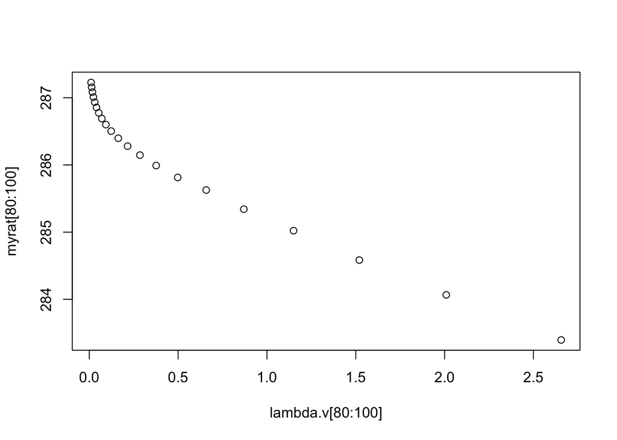

```r
my.l2=function(betas){#calculate l2 norm
  sqrt(sum(betas^2))}
  ls2=c()
  for (i in 1:100){
    ls2=c(ls2, my.l2(coeffs[-c(1,2),i]))
  }
nvars <- sapply(B.train2, is.numeric)
B.train2[, nvars] <- scale(B.train2[, nvars])
cvars <- sapply(B.train2, is.factor)
B.train2[, cvars] <- lapply(B.train2[, cvars], as.factor)

lslm2 <- lm(Birth.Weight..g. ~. - X, data = B.train2)
lscoeff <- coef(lslm2)
ls2ls <- sqrt(sum(lscoeff^2, na.rm = TRUE))
myrat <- ls2 / ls2ls
plot(lambda.v[80:100], myrat[80:100])
```

```r
births2 <- na.omit(births)
x2 <- model.matrix(Birth.Weight..g. ~., data = births2)
y2 <- births2$Birth.Weight..g.
model.ridgeD <- glmnet(x2, y2, alpha = 0, lambda = lambda.v)

cv.output <- cv.glmnet(x2, y2, alpha = 0)
bestlamb.cv <- cv.output$lambda.min
bestlamb.cv
```

```
## [1] 59.2054
```

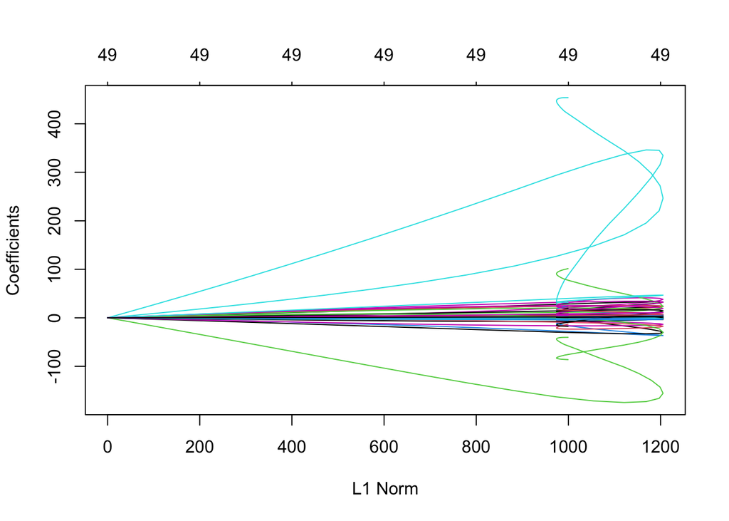

```r
plot(model.ridge)
```